# Modeling COVID Cases with a Simple SIR model

2024-08-20

```r
library(tidyverse)
library(scales)

CASES_URL <- "https://github.com/CSSEGISandData/COVID-19/raw/master/csse_covid_19_data/csse_covid_19_time_series/time_series_covid19_confirmed_global.csv"

DEATHS_URL <- "https://github.com/CSSEGISandData/COVID-19/raw/master/csse_covid_19_data/csse_covid_19_time_series/time_series_covid19_deaths_global.csv"

RECOVERED_URL <- "https://github.com/CSSEGISandData/COVID-19/raw/master/csse_covid_19_data/csse_covid_19_time_series/time_series_covid19_recovered_global.csv"
```

# Executive Summary

In this analysis, we attempt to model the evolution of the number of cases and deaths due to COVID in the US using a rudimentary [SIR model](https://en.wikipedia.org/wiki/Compartmental_models_in_epidemiology#The_SIR_model). In particular, we estimate the parameters of the SIR model using data from the early days of the pandemic and solve the model forward to generate a forecast of cases and deaths.

We find that a naive implementation of the SIR model predicts a spike in cases during the summer of 2020 that did not occur. This is likely due to interventions such as social distancing that slowed the spread of the virus. Additionally, it is known that there is systematic under-reporting of recoveries in the US for the time period studied, which would tend to cause over-estimation of recovery time and, therefore, future infected population.

# Data Import

Below, we import and tidy the Johns Hopkins cases/deaths/recovered data and compile it into a single time series. The grain of this time series is weekly since most reporting agencies updated their data weekly.

A major quality issue of note is that recoveries are widely considered under-reported in the data, to a point where the maintainers of this dataset [discontinued support](https://github.com/CSSEGISandData/COVID-19/issues/4465) for recovery figures in late November. In the absence of better information, we will use the recovery figures as provided, but it will be important to note this issue in the data as we draw inferences later.

```r
clean_table <- function(tbl, values_to) {
    tbl %>%
        rename(province_state = `Province/State`, country_region = `Country/Region`, lat = Lat, long = Long) %>%
        pivot_longer(
            cols = -c(province_state, country_region, lat, long),
            names_to = "date",
            names_transform = mdy,
            values_to = values_to
        )
}

summarize_table <- function(tbl, value) {
    tbl %>%
        filter(country_region == "US", is.na(province_state)) %>%
        group_by(week = floor_date(date, unit = "week")) %>%
        summarize({{value}} := sum({{value}}, na.rm = TRUE))
}


col_spec <- cols(
    `Province/State` = col_character(),
    `Country/Region` = col_character(),
    .default = col_double()
)

cases <-
    CASES_URL %>%
    read_csv(col_types = col_spec) %>%
    clean_table(values_to = "cases") %>%
    summarize_table(cases)

deaths <-
    DEATHS_URL %>%
    read_csv(col_types = col_spec) %>%
    clean_table(values_to = "deaths") %>%
    summarize_table(deaths)

recovered <-
    RECOVERED_URL %>%
    read_csv(col_types = col_spec) %>%
    clean_table(values_to = "recovered") %>%
    summarize_table(recovered)
```

# Modeling new cases with SIR

## Background

[SIR](https://en.wikipedia.org/wiki/Compartmental_models_in_epidemiology#The_SIR_model) is a simple compartmental epidemiological model in which a fixed population of people are in one of three states:

- *$S$: Susceptible*: People who are uninfected and may become infected via contact with infected individuals
- *$I$: Infected*: People with the disease who can spread
- *$R$: Removed*: People who have had the disease and can no longer infect susceptible people, whether by successful recovery or by death.

The model is dictated by a set of three differential equations
$$\frac{dS}{dt} = -\beta SI$$
$$\frac{dI}{dt} = \beta SI - \gamma I$$
$$\frac{dR}{dt} = \gamma I$$
where $\beta$ is a parameter representing the level of infectiousness of the disease and $\gamma$ is a parameter controlling the speed of removal from the infectious population. Additionally, the model assumes a static population $S_t + I_t + R_t = N$ for fixed $N$.

## Modeling

For our purposes, we will focus on forecasting the number of cases in the time period May - November 2020.

To do this, we will

1. Calculate actual values for $S_t, I_t, R_t$ using the number of new cases, deaths, recoveries, and the approximate population of the US in 2020.
2. Estimate the parameters $\beta$ and $\gamma$ using the data from the time period January - April 2020
3. Recursively estimate $S_t$, $I_t$, $R_t$ according to the discretized form of the above differential equations
4. Calculate predicted new cases as $S_t - S_{t-1}$

Below, we perform step 1 and show the values for $S_t, I_t, R_t$ calculated.

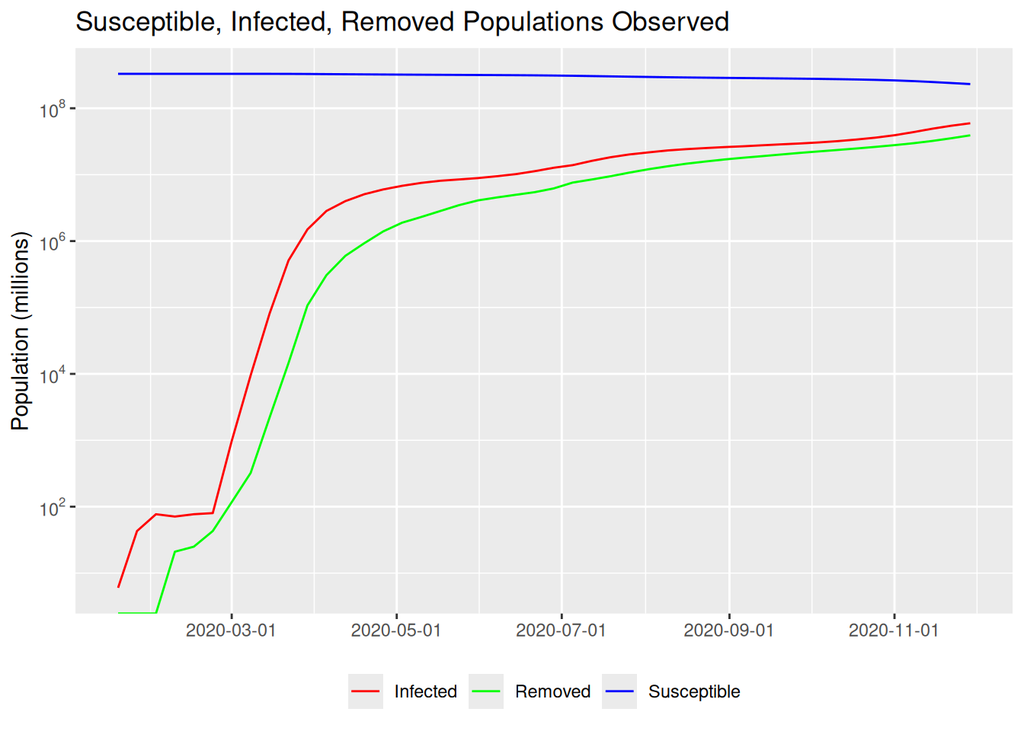

```r
cases_deaths_recovered <-
    cases %>%
    full_join(deaths, by = "week") %>%
    full_join(recovered, by = "week") %>%
    mutate(
        across(c("cases", "deaths", "recovered"), ~ coalesce(., 0))
    ) %>%
    filter(week <= ymd("2021-12-01"))

# approximate population of the US around 2020
# https://www.census.gov/quickfacts/fact/table/US/POP010220
POPULATION <- 330000000

add_sir <- function(tbl, starting_population) {
    tbl %>%
        mutate(
            susceptible = starting_population - cases,
            infected = cases - deaths - recovered,
            removed = deaths + recovered
        )
}

sir_tbl <- add_sir(cases_deaths_recovered, POPULATION)

cases_deaths_recovered %>%
    add_sir(POPULATION) %>%
    filter(week <= ymd('2020-12-01')) %>%
    ggplot(aes(week)) +
    geom_line(aes(y = susceptible, color = "susceptible")) +
    geom_line(aes(y = infected, color = "infected")) +
    geom_line(aes(y = removed, color = "removed")) +
    scale_x_date(breaks = breaks_width("2 months"), labels = label_date()) +
    scale_y_log10(label = label_log()) +
    scale_color_manual(
        name = NULL,
        values = c("susceptible" = "blue", "infected" = "red", "removed" = "green"),
        labels = c("susceptible" = "Susceptible", "infected" = "Infected", "removed" = "Removed"),
    ) +
    labs(
        title = "Susceptible, Infected, Removed Populations Observed"
    ) +
    xlab(NULL) +
    ylab("Population (millions)") +
    theme(legend.position = "bottom")
```

Now, we perform step 2. We implement an extremely crude approach to estimating the parameters $\beta$ and $\gamma$. We leverage the differential equations of the SIR model dictating $dS/dt$ and $dR/dt$, giving us
$$\beta = -\frac{dS/dt}{SI}$$
$$\gamma = \frac{dR/dt}{I}$$
Discretizing, we have
$$\beta_t = -\frac{S_t - S_{t-1}}{S_{t-1} I_{t - 1}}$$
$$\gamma_t = \frac{R_t - R_{t - 1}}{I_{t - 1}}$$
We assume that $\beta$ and $\gamma$ are fixed, and estimate $\beta$ and $\gamma$ to be the median of $\beta_t$ and $\gamma_t$, respectively, over every week $t$ in Jan - Apr 2020. We choose a median instead of the canonical mean to minimize the effects of outliers in the data. The estimated values are shown below.

```r
train_tbl <-
    sir_tbl %>%
    filter(week <= ymd('2020-05-01'))

est_parameters <-
    train_tbl %>%
    mutate(
        prev_susceptible_times_infected = lag(susceptible * infected),
        prev_infected = lag(infected),
        est_beta = -(susceptible - lag(susceptible)) / prev_susceptible_times_infected,
        est_gamma = (removed - lag(removed)) / prev_infected
    ) %>%
    summarize(beta = median(est_beta, na.rm = TRUE), gamma = median(est_gamma, na.rm = TRUE))

est_parameters
```

```
## # A tibble: 1 × 2
##            beta gamma
##           <dbl> <dbl>
## 1 0.00000000276 0.143
```

Now, we perform step 3 and use the discretized version of the SIR model and the estimated values of $\beta$ and $\gamma$ to project the size of each compartment forward in time.
$$S_{t+1} = S_t - \beta S_t I_t$$
$$I_{t+1} = I_t + \beta S_t I_t - \gamma I_t$$
$$R_{t+1} = R_t + \gamma I_t$$
Below, we show the projected population of infected and recovered people using this method, as well as the actual populations. Notice that the SIR model expects a giant spike in infections in the middle of summer that does not occur.

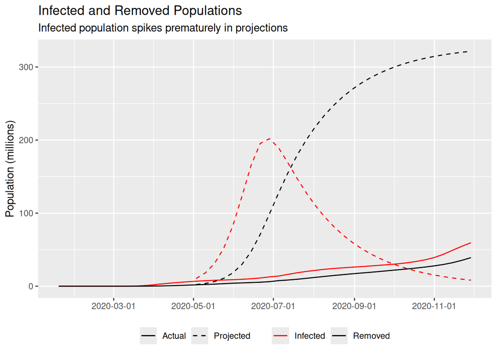

```r
calc_forward <- function(date, s, i, r, beta, gamma, n_periods) {
    out_s <- rep(NA, n_periods)
    out_i <- rep(NA, n_periods)
    out_r <- rep(NA, n_periods)
    for (t in 1:n_periods) {
        if (t == 1) {
            prev_s <- s
            prev_i <- i
            prev_r <- r
        } else {
            prev_s <- out_s[t - 1]
            prev_i <- out_i[t - 1]
            prev_r <- out_r[t - 1]
        }
        out_s[t] = prev_s - beta * prev_s * prev_i
        out_i[t] = prev_i + beta * prev_s * prev_i - gamma * prev_i
        out_r[t] = prev_r + gamma * prev_i
    }

    tibble(
        week = date + period(week = 1:n_periods),
        pred_susceptible = out_s,
        pred_infected = out_i,
        pred_removed = out_r
    )
}

last_state <-
    train_tbl %>%
    filter(week == max(week)) %>%
    select(week, s = susceptible, i = infected, r = removed)

predictions <-
    calc_forward(last_state$week, last_state$s, last_state$i, last_state$r, est_parameters$beta, est_parameters$gamma, 33)

sir_tbl %>%
    filter(week <= ymd('2020-12-01')) %>%
    left_join(predictions, by = "week") %>%
    ggplot(aes(week)) +
    geom_line(aes(y = infected, color = "infected", linetype = "actual")) +
    geom_line(aes(y = pred_infected, color = "infected", linetype = "predicted")) +
    geom_line(aes(y = removed, color = "removed", linetype = "actual")) +
    geom_line(aes(y = pred_removed, color = "removed", linetype = "predicted")) +
    scale_color_manual(
        name = NULL,
        values = c(infected = "red", removed = "black"),
        labels = c(infected = "Infected", removed = "Removed")
    ) +
    scale_linetype_manual(
        name = NULL,
        values = c(actual = "solid", predicted = "dashed"),
        labels = c(actual = "Actual", predicted = "Projected")
    ) +
    scale_x_date(breaks = breaks_width("2 month"), labels = label_date()) +
    scale_y_continuous(labels = label_number(scale = 1e-6)) +
    labs(
        title = "Infected and Removed Populations",
        subtitle = "Infected population spikes prematurely in projections"
    ) +
    xlab(NULL) +
    ylab("Population (millions)") +
    theme(legend.position = "bottom")
```

Finally, we perform step 4 and translate these projections into new case projections. Again, the SIR model expects a huge spike in new cases during the summer that did not come to pass.

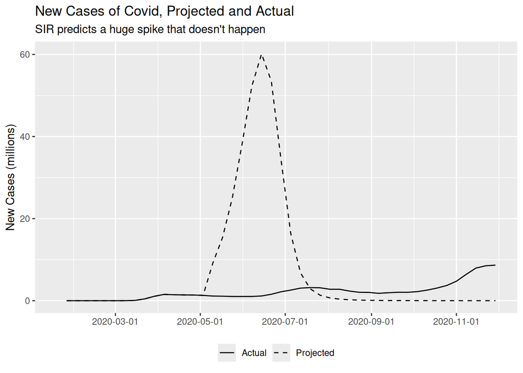

```r
sir_tbl %>%
    filter(week <= ymd('2020-12-01')) %>%
    left_join(predictions, by = "week") %>%
    mutate(
        actual_new_cases = lag(susceptible) - susceptible,
        pred_new_cases = (lag(pred_susceptible) - pred_susceptible) %>% coalesce(actual_new_cases)
    ) %>%
    ggplot(aes(week)) +
    geom_line(aes(y = actual_new_cases, linetype = "actual")) +
    geom_line(aes(y = pred_new_cases, linetype = "predicted")) +
    scale_linetype_manual(
        name = NULL,
        values = c(actual = "solid", predicted = "dashed"),
        labels = c(actual = "Actual", predicted = "Projected")
    ) +
    scale_x_date(breaks = breaks_width("2 month"), labels = label_date()) +
    scale_y_continuous(labels = label_number(scale = 1e-6)) +
    labs(
        title = "New Cases of Covid, Projected and Actual",
        subtitle = "SIR predicts a huge spike that doesn't happen"
    ) +
    xlab(NULL) +
    ylab("New Cases (millions)") +
    theme(legend.position = "bottom")
```

# Discussion/Bias in the Data

Clearly, the SIR model failed spectacularly when it came to predicting the number of new cases in the data. There are a couple of possible explanations in my view.

- Our estimation methods for $\beta$ and $\gamma$ assume that these parameters are fixed throughout the pandemic. This is of course very unlikely to be true in the data, given that governments around the world quickly implemented interventions like social distancing and travel restrictions that slowed the spread of the virus down dramatically compared to earlier in the year.
- Recoveries are thought to be [under-reported](https://covidtracking.com/about-data/faq#why-have-you-stopped-reporting-national-recoveries) in the data. The maintainers explain that state-level data on recoveries and active cases are not well standardized, and many large states do not even report report recoveries. For this reason, it’s likely that we are under-estimating the rate at which people are removed from the infected bucket, causing a premature spike in the model.

I would propose the following areas for improvement in the modeling techniques employed here:

- Allowing for changes in $\beta$ and $\gamma$ over time would likely have yielded results which are more responsive to changes in the spread of the disease that arise from anticipated human interventions
- In the absence of accurate recovery data, it may be difficult to get a reliable estimate for $\gamma$. More sophisticated methods of inferring recovery rates could be used. For example, instead of relying on raw numbers, we could infer the number of recoveries from the number of cases and an estimate of how long it takes to recover from the disease taken from empirical studies.